# Assignment 2

Huang Yingshan, Kahlbacher Fabian, Wattenberg Yannick, Aggeler Samuel

10/11/2021

# Task 1

```r
source("MHSim.R")
```

```r
communication <- as.matrix(read.csv("data/communication.csv", header=F))
```

## 2)

```r
set.seed(123)
```

### 2.1)

```r
net_0 <- matrix(0,38,38)

sim_net <- MarkovChain(
  net=net_0,
  theta1=-0.6,
  theta2=1.5,
)
```

### 2.2)

```r
communication_edge <- z1(communication)
communication_mutual <- z2(communication)
communication_edge
```

```
## [1] 311
```

```r
communication_mutual
```

```
## V1
## 74
```

```r
sim_net_edge <- mean(sim_net$statSim[,1])
sim_net_mutual <- mean(sim_net$statSim[,2])
sim_net_edge
```

```
## [1] 775.134
```

```r
sim_net_mutual
```

```
## [1] 275.879
```

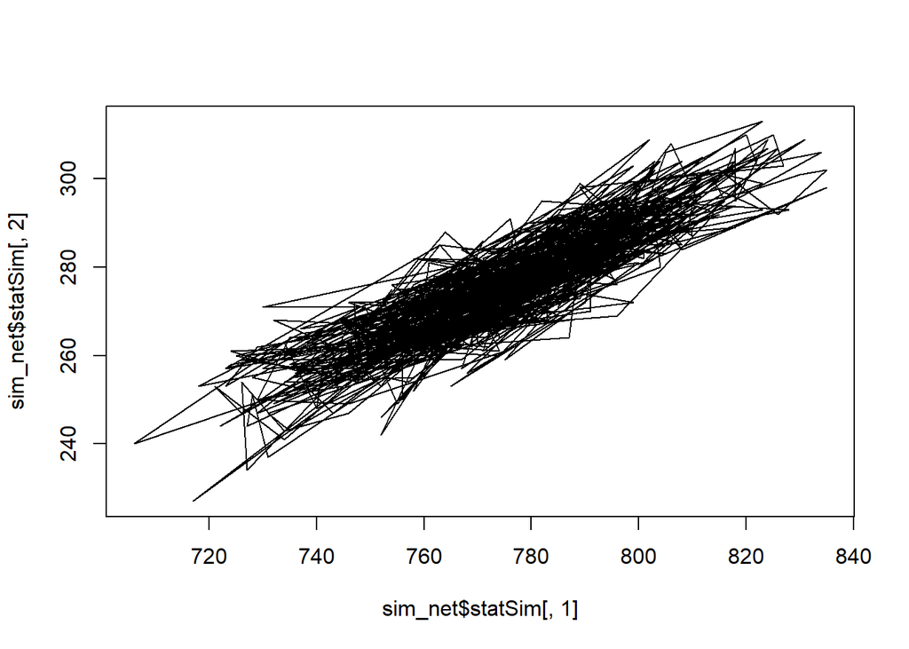

```r
plot(sim_net$statSim[,1], sim_net$statSim[,2], type='l')
```

The observed adjacency matrix has 311 edges and 74 reciprocal dyads, while the mean count of edges and reciprocal dyads of simulated networks based on parameters $\theta_1=-0.6,\theta_2=1.5$ is 775.134 and 275.879, which implies that the suggested values of parameters cannot be used to describe communication networks. So they are not good estimates of parameters for communication networks.

## 3)

From the dyads-edge plot of simulated networks using suggested estimates in (2), we know counts of both reciprocal dyads and edges are larger than the counts of the observed network. Thus, we should decrease both the estimated coefficient of edge counts ($\theta_1$) and estimated coefficient of reciprocal dyad counts ($\theta_2$). First, we control $\theta_2$ and adjust $\theta_1$ to -1.

```r
sim_net_2 <- MarkovChain(
  net=net_0,
  theta1=-1,
  theta2=1.5,
)

sim_net_2_edge <- mean(sim_net_2$statSim[,1])
sim_net_2_mutual <- mean(sim_net_2$statSim[,2])
sim_net_2_edge
```

```
## [1] 585.274
```

```r
sim_net_2_mutual
```

```
## [1] 182.295
```

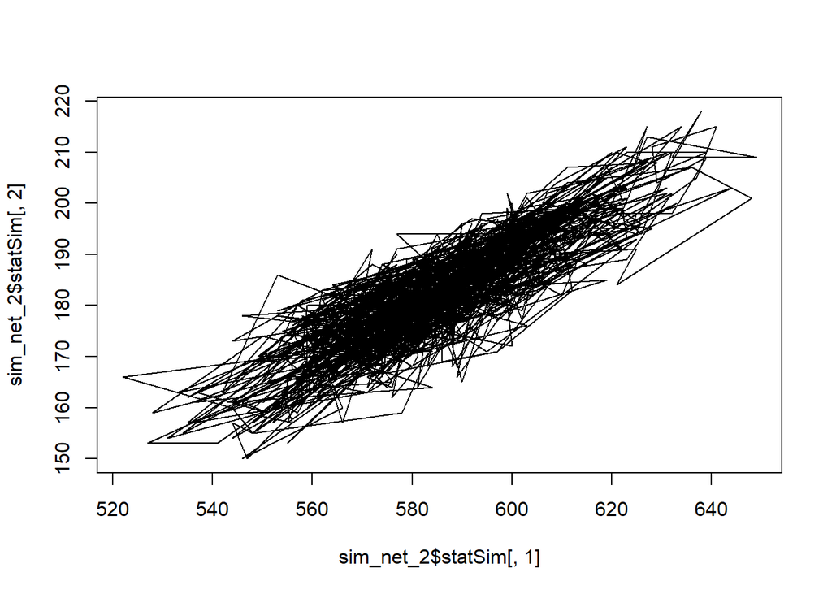

```r
plot(sim_net_2$statSim[,1], sim_net_2$statSim[,2], type='l')
```

From the simulation result, we obtain expected value of edge and mutual dyad counts which are 585.274 and 182.295. This is closer to the observed values, but still larger. Then, we keep decreasing $\theta_1$ to -1.5.

```r
sim_net_3 <- MarkovChain(
  net=net_0,
  theta1=-1.5,
  theta2=1.5,
)
```

```r
sim_net_3_edge <- mean(sim_net_3$statSim[,1])
sim_net_3_mutual <- mean(sim_net_3$statSim[,2])
sim_net_3_edge
```

```
## [1] 376.447
```

```r
sim_net_3_mutual
```

```
## [1] 94.311
```

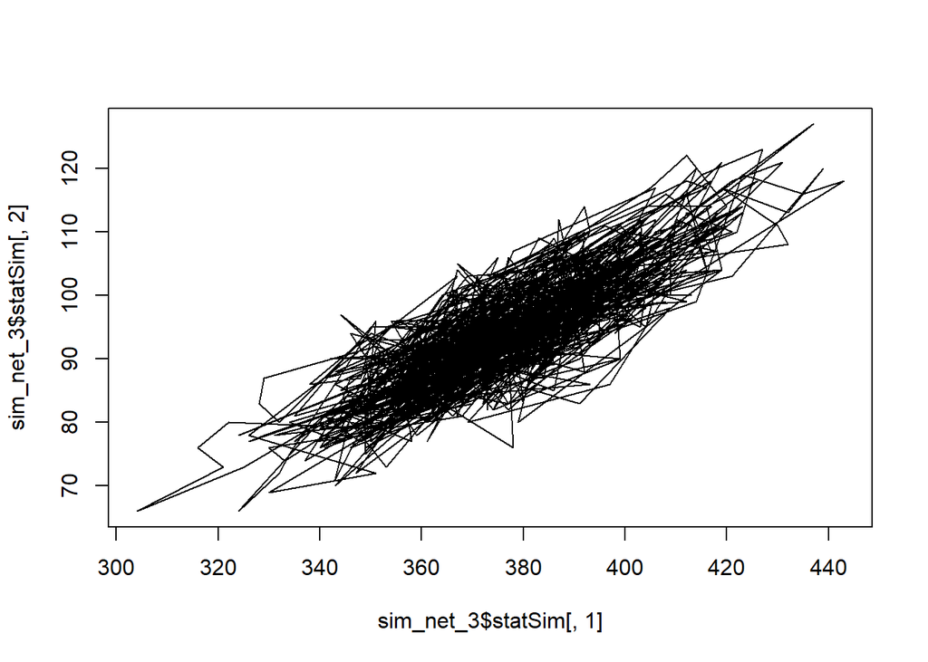

```r
plot(sim_net_3$statSim[,1], sim_net_3$statSim[,2], type='l')
```

From the simulation results above, the expected value of edges and reciprocal dyads change to 376.447 and 94.311, which is rather closer to the observed values but still larger than 311 and 74. Then, we decrease $\theta_1$ but decrease the step size from 0.5 to 0.1, changing $\theta_1$ from -1.5 to -1.6.

```r
sim_net_4 <- MarkovChain(
  net=net_0,
  theta1=-1.6,
  theta2=1.5,
)
```

```r
sim_net_4_edge <- mean(sim_net_4$statSim[,1])
sim_net_4_mutual <- mean(sim_net_4$statSim[,2])
sim_net_4_edge
```

```
## [1] 340.39
```

```r
sim_net_4_mutual
```

```
## [1] 80.81
```

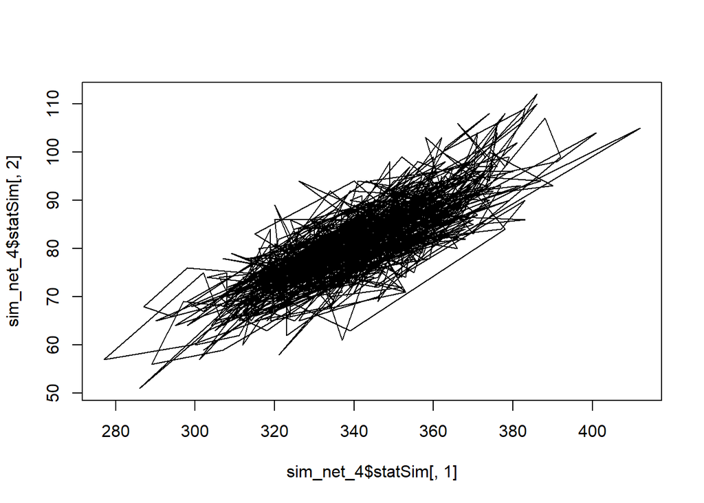

```r
plot(sim_net_4$statSim[,1], sim_net_4$statSim[,2], type='l')
```

From the simulation results above, the expected value of edges and reciprocal dyads change to 340.39 and 80.81, which is rather closer to the observed values, but still a bit larger. Thus, we keep decreasing $\theta_1$ with a step size of 0.1, changing $\theta_1$ to -1.7.

```r
sim_net_5 <- MarkovChain(
  net=net_0,
  theta1=-1.7,
  theta2=1.5,
)
```

```r
sim_net_5_edge <- mean(sim_net_5$statSim[,1])
sim_net_5_mutual <- mean(sim_net_5$statSim[,2])
sim_net_5_edge
```

```
## [1] 306.386
```

```r
sim_net_5_mutual
```

```
## [1] 68.697
```

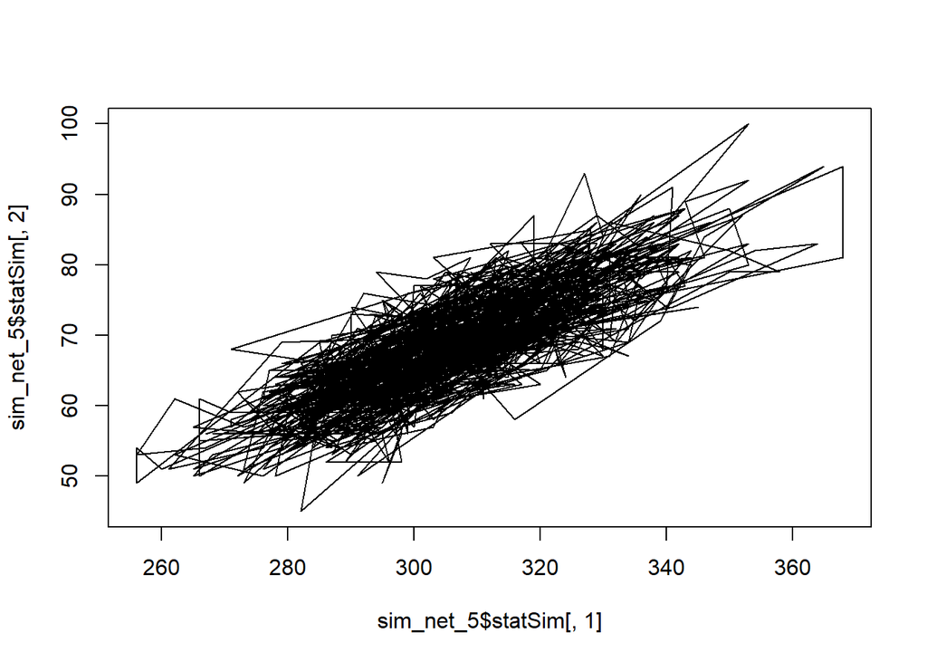

```r
plot(sim_net_5$statSim[,1], sim_net_5$statSim[,2], type='l')
```

From the simulation results above, the expected values of edges and reciprocal dyads change to 306.386 and 68.697, which are closer to the observed values but a bit smaller this time. Thus, we keep $\theta_1$ fixed and increase $\theta_2$ with a small step size of 0.1, changing $\theta_2$ from 1.5 to 1.6.

```r
sim_net_6 <- MarkovChain(
  net=net_0,
  theta1=-1.7,
  theta2=1.6,
)
```

```r
sim_net_6_edge <- mean(sim_net_6$statSim[,1])
sim_net_6_mutual <- mean(sim_net_6$statSim[,2])
sim_net_6_edge
```

```
## [1] 318.441
```

```r
sim_net_6_mutual
```

```
## [1] 75.591
```

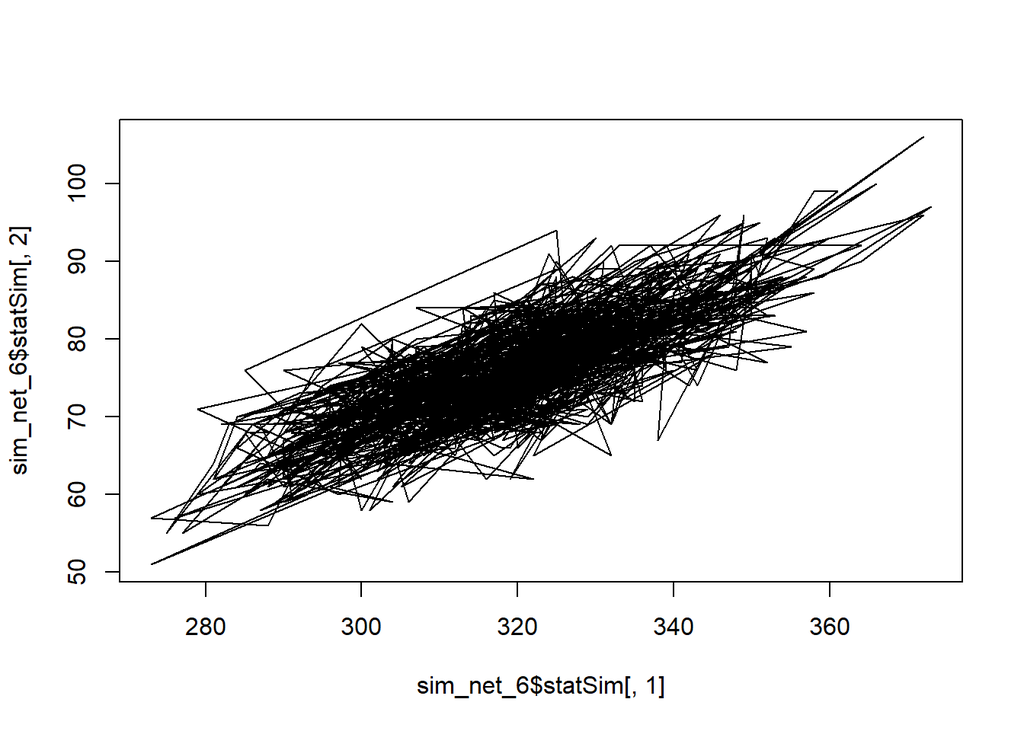

```r
plot(sim_net_6$statSim[,1], sim_net_6$statSim[,2], type='l')
```

From the simulation result, the expected values of edges and reciprocal dyads are 318.441 and 75.591, which are close to the observed values 311 and 74. Thus, $\theta_1=-1.7,\theta_2=1.6$ seem like reasonable parameters to describe the observed communication network.